# NYPD Shooting Data

2022-08-14

This report will analyze the historical NYPD Shooting Data as part of DTSA5301: Data Science as a Field.

```r
url_in <- "https://data.cityofnewyork.us/api/views/833y-fsy8/rows.csv?accessType=DOWNLOAD"

shooting_data <- read.csv(url_in)
```

I will view the summary and first 6 rows of the dataset to get an initial understanding of the contents.

```r
summary(shooting_data)
```

```
##   INCIDENT_KEY        OCCUR_DATE         OCCUR_TIME            BORO
##  Min.   :  9953245   Length:25596       Length:25596       Length:25596
##  1st Qu.: 61593633   Class :character   Class :character   Class :character
##  Median : 86437258   Mode  :character   Mode  :character   Mode  :character
##  Mean   :112382648
##  3rd Qu.:166660833
##  Max.   :238490103
##
##     PRECINCT      JURISDICTION_CODE LOCATION_DESC      STATISTICAL_MURDER_FLAG
##  Min.   :  1.00   Min.   :0.0000    Length:25596       Length:25596
##  1st Qu.: 44.00   1st Qu.:0.0000    Class :character   Class :character
##  Median : 69.00   Median :0.0000    Mode  :character   Mode  :character
##  Mean   : 65.87   Mean   :0.3316
##  3rd Qu.: 81.00   3rd Qu.:0.0000
##  Max.   :123.00   Max.   :2.0000
##                   NA's   :2
##  PERP_AGE_GROUP       PERP_SEX          PERP_RACE         VIC_AGE_GROUP
##  Length:25596       Length:25596       Length:25596       Length:25596
##  Class :character   Class :character   Class :character   Class :character
##  Mode  :character   Mode  :character   Mode  :character   Mode  :character
##
##
##
##
##    VIC_SEX            VIC_RACE           X_COORD_CD        Y_COORD_CD
##  Length:25596       Length:25596       Min.   : 914928   Min.   :125757
##  Class :character   Class :character   1st Qu.:1000011   1st Qu.:182782
##  Mode  :character   Mode  :character   Median :1007715   Median :194038
##                                        Mean   :1009455   Mean   :207894
##                                        3rd Qu.:1016838   3rd Qu.:239429
##                                        Max.   :1066815   Max.   :271128
##
##     Latitude       Longitude        Lon_Lat
##  Min.   :40.51   Min.   :-74.25   Length:25596
##  1st Qu.:40.67   1st Qu.:-73.94   Class :character
##  Median :40.70   Median :-73.92   Mode  :character
##  Mean   :40.74   Mean   :-73.91
##  3rd Qu.:40.82   3rd Qu.:-73.88
##  Max.   :40.91   Max.   :-73.70
##
```

```r
head(shooting_data)
```

```
##   INCIDENT_KEY OCCUR_DATE OCCUR_TIME      BORO PRECINCT JURISDICTION_CODE
## 1     24050482 08/27/2006   05:35:00     BRONX       52                 0
## 2     77673979 03/11/2011   12:03:00    QUEENS      106                 0
## 3    226950018 04/14/2021   21:08:00     BRONX       42                 0
## 4    237710987 12/10/2021   19:30:00     BRONX       52                 0
## 5    224701998 02/22/2021   00:18:00 MANHATTAN       34                 0
## 6    225295736 03/07/2021   06:15:00  BROOKLYN       75                 0
##     LOCATION_DESC STATISTICAL_MURDER_FLAG PERP_AGE_GROUP PERP_SEX
## 1                                    true
## 2                                   false
## 3 COMMERCIAL BLDG                    true
## 4                                   false
## 5                                   false
## 6                                    true          25-44        M
##        PERP_RACE VIC_AGE_GROUP VIC_SEX       VIC_RACE X_COORD_CD Y_COORD_CD
## 1                        25-44       F BLACK HISPANIC    1017542   255918.9
## 2                          65+       M          WHITE    1027543   186095.0
## 3                        18-24       M          BLACK    1009489   243050.0
## 4                        25-44       M          BLACK    1017440   256046.0
## 5                        25-44       M BLACK HISPANIC    1005426   254690.0
## 6 BLACK HISPANIC         25-44       M WHITE HISPANIC    1020492   187865.0
##   Latitude Longitude                                       Lon_Lat
## 1 40.86906 -73.87963  POINT (-73.87963173099996 40.86905819000003)
## 2 40.67737 -73.84392 POINT (-73.84392019199998 40.677366895000034)
## 3 40.83376 -73.90880  POINT (-73.90879517699994 40.83376365400005)
## 4 40.86941 -73.88000  POINT (-73.87999831299999 40.86940749200004)
## 5 40.86572 -73.92344  POINT (-73.92344088699997 40.86572268100008)
## 6 40.68226 -73.86933  POINT (-73.86933111399996 40.68225681500007)
```

Based upon the initial summary, the “Occur Date” and “Occur Time” columns are character-type. I am going to combine the occur date and times into one column, then update the data type using lubridate.

```r
library(lubridate)
library(tidyr)
library(dplyr)
shooting_data <- shooting_data %>% unite("Occur_Date_Time", c(OCCUR_DATE, OCCUR_TIME), sep=" ", na.rm=TRUE, remove=FALSE)

shooting_data <- shooting_data %>%
  mutate(Occur_Date_Time=as_datetime(Occur_Date_Time, format = "%m/%d/%Y %H:%M:%S", tz = "America/New_York"))

##Remove original OCCUR_DATE and OCCUR_TIME as they are now united
shooting_data <- shooting_data %>%
     select(-c(OCCUR_DATE, OCCUR_TIME))
```

The jurisdiction code refers to where the incident occurred: 0=Patrol, 1=Transit, 2=Housing. I will change the jurisdiction code column to a character type rather than integer, since this is categorical data.

```r
shooting_data <- shooting_data %>%
  mutate(JURISDICTION_CODE=as.character(JURISDICTION_CODE))
```

Next, I noticed that the provided “Lon_Lat” column is a combination of the given Latitude and Longitudes, and I don’t need all three columns. I will remove Lon_Lat as this is a character class.

Additionally, I reviewed the NYPD Shooting Data footnotes that accompany this dataset. I found that “X_COORD_CD” and “Y_COORD_CD” are topographic coordinates. I do not believe these will be used in the analysis and so may be removed.

```r
shooting_data <- shooting_data %>%
  select(-c(Lon_Lat, X_COORD_CD, Y_COORD_CD))

#Check the summary to ensure all data types are correct and no extraneous columns remain.
summary(shooting_data)
```

```
##   INCIDENT_KEY       Occur_Date_Time                   BORO
##  Min.   :  9953245   Min.   :2006-01-01 02:00:00   Length:25596
##  1st Qu.: 61593633   1st Qu.:2009-05-10 04:05:00   Class :character
##  Median : 86437258   Median :2012-08-26 01:05:00   Mode  :character
##  Mean   :112382648   Mean   :2013-06-14 04:24:56
##  3rd Qu.:166660833   3rd Qu.:2017-07-01 00:20:15
##  Max.   :238490103   Max.   :2021-12-31 19:23:00
##     PRECINCT      JURISDICTION_CODE  LOCATION_DESC      STATISTICAL_MURDER_FLAG
##  Min.   :  1.00   Length:25596       Length:25596       Length:25596
##  1st Qu.: 44.00   Class :character   Class :character   Class :character
##  Median : 69.00   Mode  :character   Mode  :character   Mode  :character
##  Mean   : 65.87
##  3rd Qu.: 81.00
##  Max.   :123.00
##  PERP_AGE_GROUP       PERP_SEX          PERP_RACE         VIC_AGE_GROUP
##  Length:25596       Length:25596       Length:25596       Length:25596
##  Class :character   Class :character   Class :character   Class :character
##  Mode  :character   Mode  :character   Mode  :character   Mode  :character
##
##
##
##    VIC_SEX            VIC_RACE            Latitude       Longitude
##  Length:25596       Length:25596       Min.   :40.51   Min.   :-74.25
##  Class :character   Class :character   1st Qu.:40.67   1st Qu.:-73.94
##  Mode  :character   Mode  :character   Median :40.70   Median :-73.92
##                                        Mean   :40.74   Mean   :-73.91
##                                        3rd Qu.:40.82   3rd Qu.:-73.88
##                                        Max.   :40.91   Max.   :-73.70
```

### Visualization and Analysis

The first question I’d like to answer is: how does the number of incidents vary against the age of the victim?

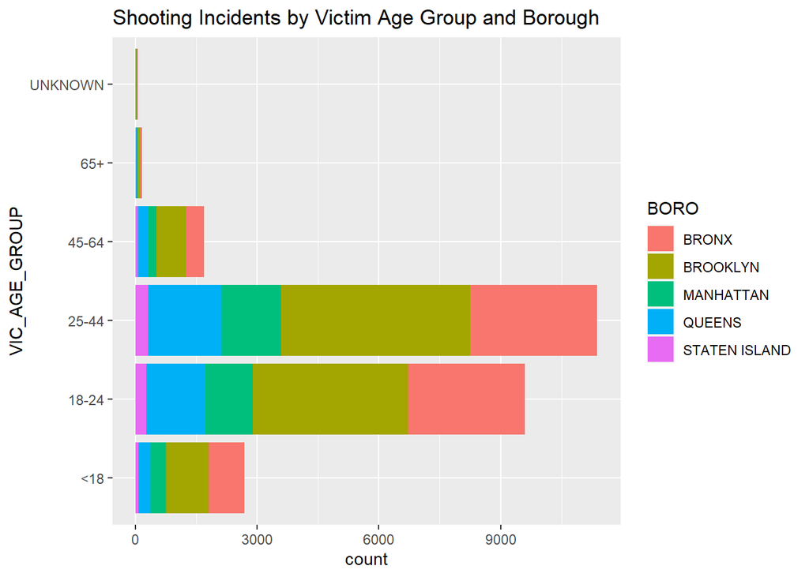

```r
library(ggplot2)
ggplot(shooting_data, aes(fill=BORO, y=VIC_AGE_GROUP)) +
  geom_bar(position = "stack") +
  ggtitle("Shooting Incidents by Victim Age Group and Borough")
```

It appears that the highest number of shooting incidents across all victim age groups is in Brooklyn. I will summarize the data by borough to check.

```r
shooting_data %>% group_by(BORO) %>% summarise(n = n())
```

```
## # A tibble: 5 x 2
##   BORO              n
##   <chr>         <int>
## 1 BRONX          7402
## 2 BROOKLYN      10365
## 3 MANHATTAN      3265
## 4 QUEENS         3828
## 5 STATEN ISLAND   736
```

So yes, the most shootings have occurred in Brooklyn. This begs the question: is Brooklyn simply the most populated borough? How do these shooting counts differ as percentages of the population?

As an additional analysis, I am choosing to create a heatmap of the shooting counts by latitude & longitude. This will give more granularity to the shooting by borough analysis, and look at which part of New York City has the densest concentration of shootings.

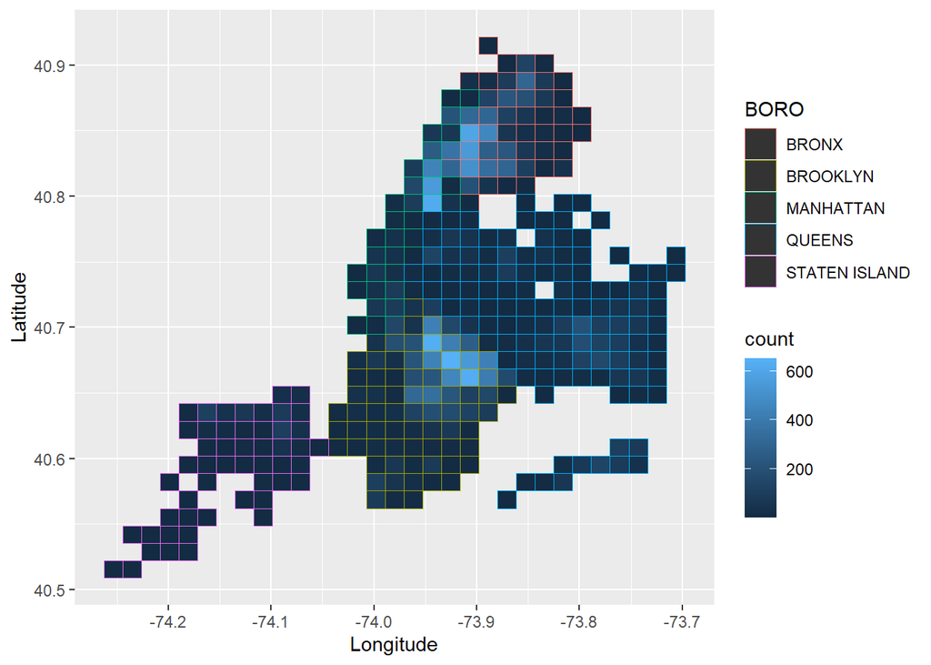

```r
ggplot(shooting_data, aes(x=Longitude, y=Latitude, col = BORO)) + geom_bin_2d()
```

It is now clear that the north side of Brooklyn, on the border with Queens, has the highest density of shootings, followed by the diagonal swath through Manhattan and the Bronx.

This graphic then begs the question: what landmarks are located in those areas? Are they busy intersections? Or perhaps extra-heavily populated housing?

### Modeling the Number of Shootings

The previous two graphics showed that the number of shootings depended on the victim’s age group and the borough in which it occurred, so those categories will be used to model the number of shootings.

```r
#Try to guess the number of shootings based upon the BORO and victim age group

boro_by_age <- shooting_data %>% group_by(BORO, VIC_AGE_GROUP) %>% summarize(number_shootings = n()) %>% subset(VIC_AGE_GROUP != "UNKNOWN")
```

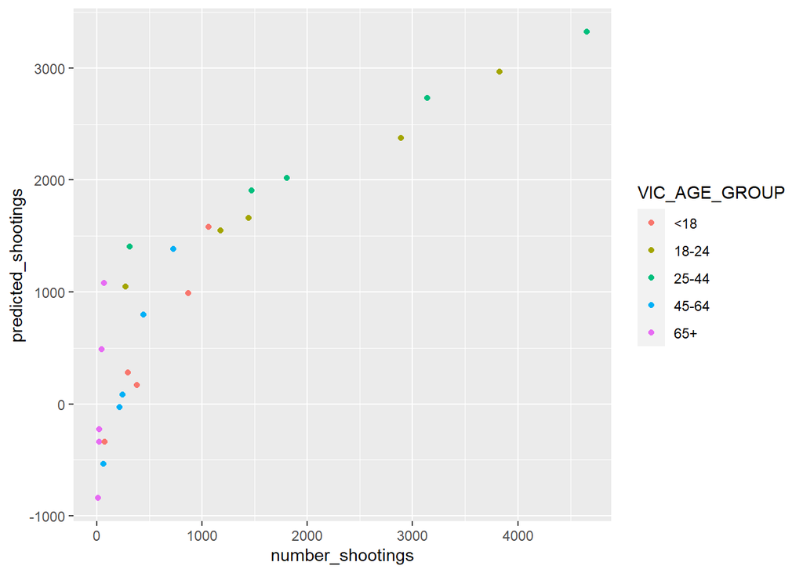

```r
model <- lm(number_shootings ~ BORO + VIC_AGE_GROUP, boro_by_age)

boro_by_age <- boro_by_age %>% ungroup() %>% mutate(predicted_shootings = predict(model))

ggplot(boro_by_age, aes(number_shootings, predicted_shootings, color = VIC_AGE_GROUP)) + geom_point()
```

### Sources of Bias

Much of the potential bias in this report stems from not being an NYC native, meaning that prior familiarity with New York shootings is limited to the news or popular culture. Additionally, having lived in suburban areas for most of my life, my understanding of the specific intricacies and potential tensions that would motivate shooting violence are limited and may contain assumptions. In an effort to minimize this bias, I looked at the information from (1) columns which had more complete entries, therefore minimizing bias in aggregating data, and (2) a geographic perspective. The geographic analysis leads to many questions, but doesn’t impart as much bias in the representation of the data.

## Conclusion

Initial analysis of the Historical NYPD Shooting Data shows that the borough of Brooklyn has had the highest number of shootings, both by age group and overall. Additionally, looking into the number of incidents by latitude and longitude shows that the densest shooting locations are on the border between boroughs: the first being between Brooklyn and Queens, followed by the border of Manhattan and the Bronx.